# Prelim EDA

Stats 2 Project Team

2019-12-03

# Background

https://www.hindawi.com/journals/bmri/2014/781670/ http://downloads.hindawi.com/journals/bmri/2014/781670.pdf

# Data Set

https://archive.ics.uci.edu/ml/datasets/diabetes+130-us+hospitals+for+years+1999-2008

The following is taken verbatim from above.

The dataset represents 10 years (1999-2008) of clinical care at 130 US hospitals and integrated delivery networks. It includes over 50 features representing patient and hospital outcomes. Information was extracted from the database for encounters that satisfied the following criteria.

- It is an inpatient encounter (a hospital admission).
- It is a diabetic encounter, that is, one during which any kind of diabetes was entered to the system as a diagnosis.
- The length of stay was at least 1 day and at most 14 days.
- Laboratory tests were performed during the encounter.
- Medications were administered during the encounter.

The data contains such attributes as patient number, race, gender, age, admission type, time in hospital, medical specialty of admitting physician, number of lab test performed, HbA1c test result, diagnosis, number of medication, diabetic medications, number of outpatient, inpatient, and emergency visits in the year before the hospitalization, etc.

## Dictionary

https://www.hindawi.com/journals/bmri/2014/781670/tab1/

## Import Data

```r
data <- read.csv("./diabetic_data.csv")
head(data)
```

```
##   encounter_id patient_nbr            race gender     age weight
## 1      2278392     8222157       Caucasian Female  [0-10)      ?
## 2       149190    55629189       Caucasian Female [10-20)      ?
## 3        64410    86047875 AfricanAmerican Female [20-30)      ?
## 4       500364    82442376       Caucasian   Male [30-40)      ?
## 5        16680    42519267       Caucasian   Male [40-50)      ?
## 6        35754    82637451       Caucasian   Male [50-60)      ?
##   admission_type_id discharge_disposition_id admission_source_id
## 1                 6                       25                   1
## 2                 1                        1                   7
## 3                 1                        1                   7
## 4                 1                        1                   7
## 5                 1                        1                   7
## 6                 2                        1                   2
##   time_in_hospital payer_code        medical_specialty num_lab_procedures
```

[output cut: 55 more lines]

Notice above that we having missing values represented by ‘?’. Let’s replace ‘?’ with NA.

```r
data <- data %>% mutate_all(~na_if(., '?'))
```

Check variables with missing values.

```r
freq.na(data)
```

```
##                          missing  %
## weight                     98569 97
## medical_specialty          49949 49
## payer_code                 40256 40
## race                        2273  2
## diag_3                      1423  1
## diag_2                       358  0
## diag_1                        21  0
## encounter_id                   0  0
## patient_nbr                    0  0
## gender                         0  0
## age                            0  0
## admission_type_id              0  0
## discharge_disposition_id       0  0
## admission_source_id            0  0
## time_in_hospital               0  0
## num_lab_procedures             0  0
## num_procedures                 0  0
## num_medications                0  0
## number_outpatient              0  0
## number_emergency               0  0
## number_inpatient               0  0
## number_diagnoses               0  0
## max_glu_serum                  0  0
## A1Cresult                      0  0
## metformin                      0  0
## repaglinide                    0  0
## nateglinide                    0  0
## chlorpropamide                 0  0
## glimepiride                    0  0
## acetohexamide                  0  0
## glipizide                      0  0
## glyburide                      0  0
## tolbutamide                    0  0
## pioglitazone                   0  0
## rosiglitazone                  0  0
## acarbose                       0  0
## miglitol                       0  0
## troglitazone                   0  0
## tolazamide                     0  0
## examide                        0  0
## citoglipton                    0  0
## insulin                        0  0
## glyburide.metformin            0  0
## glipizide.metformin            0  0
## glimepiride.pioglitazone       0  0
## metformin.rosiglitazone        0  0
## metformin.pioglitazone         0  0
## change                         0  0
## diabetesMed                    0  0
## readmitted                     0  0
```

Due to the frequency of missing data, let’s remove ‘weight’, ‘medical_specialty’, and ‘payer_code’.

```r
data <- select(data, select=-c("weight","medical_specialty","payer_code"))
```

Next, let’s remove observations where the discharge disposition is related to hospice or death, since these will not add to the possibility of being readmitted. * 11 - Expired * 13 - Hospice/Home * 14 - Hospice/Medical Facility * 19 - Expired at Home * 20 - Expired at Medical Facility * 21 - Expired at Unknown

```r
data <- data %>% filter(!data$discharge_disposition_id %in% c('11','13','14','19','20','21'))
summary(data)
```

```
##   encounter_id        patient_nbr                     race
##  Min.   :    12522   Min.   :      135   ?              :    0
##  1st Qu.: 84690342   1st Qu.: 23386748   AfricanAmerican:18772
##  Median :152232072   Median : 45417744   Asian          :  628
##  Mean   :164968866   Mean   : 54261171   Caucasian      :74220
##  3rd Qu.:230101830   3rd Qu.: 87560073   Hispanic       : 2017
##  Max.   :443867222   Max.   :189502619   Other          : 1472
##                                          NA's           : 2234
##              gender           age        admission_type_id
##  Female         :53454   [70-80):25331   Min.   :1.00
##  Male           :45886   [60-70):22059   1st Qu.:1.00
##  Unknown/Invalid:    3   [50-60):17060   Median :1.00
##                          [80-90):16434   Mean   :2.03
##                          [40-50): 9607   3rd Qu.:3.00
##                          [30-40): 3764   Max.   :8.00
##                          (Other): 5088
##  discharge_disposition_id admission_source_id time_in_hospital
##  Min.   : 1.000           Min.   : 1.000      Min.   : 1.000
##  1st Qu.: 1.000           1st Qu.: 1.000      1st Qu.: 2.000
##  Median : 1.000           Median : 7.000      Median : 4.000
##  Mean   : 3.518           Mean   : 5.731      Mean   : 4.379
##  3rd Qu.: 3.000           3rd Qu.: 7.000      3rd Qu.: 6.000
##  Max.   :28.000           Max.   :25.000      Max.   :14.000
##
##  num_lab_procedures num_procedures  num_medications number_outpatient
##  Min.   :  1.00     Min.   :0.000   Min.   : 1.00   Min.   : 0.0000
##  1st Qu.: 31.00     1st Qu.:0.000   1st Qu.:10.00   1st Qu.: 0.0000
##  Median : 44.00     Median :1.000   Median :15.00   Median : 0.0000
##  Mean   : 42.91     Mean   :1.334   Mean   :15.98   Mean   : 0.3693
##  3rd Qu.: 57.00     3rd Qu.:2.000   3rd Qu.:20.00   3rd Qu.: 0.0000
##  Max.   :132.00     Max.   :6.000   Max.   :81.00   Max.   :42.0000
##
##  number_emergency  number_inpatient      diag_1          diag_2
##  Min.   : 0.0000   Min.   : 0.0000   428    : 6663   276    : 6589
##  1st Qu.: 0.0000   1st Qu.: 0.0000   414    : 6550   428    : 6459
##  Median : 0.0000   Median : 0.0000   786    : 4015   250    : 6051
##  Mean   : 0.1984   Mean   : 0.6309   410    : 3448   427    : 4892
##  3rd Qu.: 0.0000   3rd Qu.: 1.0000   486    : 3383   401    : 3722
##  Max.   :76.0000   Max.   :21.0000   (Other):75264   (Other):71274
##                                      NA's   :   20   NA's   :  356
```

[output cut: 41 more lines]

```
##  No    :99342             No    :99341            No    :99342
##  Steady:    1             Steady:    2            Steady:    1
##
##
##
##
##
##  change     diabetesMed readmitted
##  Ch:46122   No :22624   <30:11314
##  No:53221   Yes:76719   >30:35502
##                         NO :52527
##
##
##
##
```

In the data set, we find that patients have multiple admissions. The paper suggests using only the first one to satisfy the independence assumption. So we will filter and only use the first encounter (the lowest for a given member). I wonder if this could be challenged. If the diagnosis or reason for visit is different than a previous admission, I think it could be considered statisically independent.

```r
data <- data %>% group_by(patient_nbr) %>% filter(encounter_id == min(encounter_id))
data <- ungroup(data)
```

Next, let’s create buckets for the ICD-9 diagnosis codes. We’ll use the mapping defined based on the following. https://www.hindawi.com/journals/bmri/2014/781670/tab2/

```r
replaceDX <- function(df = data, rx, replaceValue) {
  df$diag_1[grep(rx,df$diag_1)] <- replaceValue
  df$diag_2[grep(rx,df$diag_2)] <- replaceValue
  df$diag_3[grep(rx,df$diag_3)] <- replaceValue

  return(df)
}
```

```r
# Create temporary data frame of bucketed DX codes
dx <- c("diag_1","diag_2","diag_3")
dataDX <- data[dx]
dataDX[] <- lapply(data[dx], as.character)

# Circulatory
label <- "Circulatory"
rx <- number_range(390,459)
dataDX <- replaceDX(dataDX, rx, label)
dataDX <- replaceDX(dataDX, "785", label)

# Respiratory
label <- "Respiratory"
rx <- number_range(460,519)
dataDX <- replaceDX(dataDX, rx, label)
dataDX <- replaceDX(dataDX, "786", label)

# Digestive
label <- "Digestive"
rx <- number_range(520,579)
dataDX <- replaceDX(dataDX, rx, label)
dataDX <- replaceDX(dataDX, "787", label)

# Diabetes
label <- "Diabetes"
rx <- number_range(250,250.99)
dataDX <- replaceDX(dataDX, rx, label)

# Injury
label <- "Injury"
rx <- number_range(800,999)
dataDX <- replaceDX(dataDX, rx, label)

# Musculoskeletal
label <- "Musculoskeletal"
rx <- number_range(710,739)
dataDX <- replaceDX(dataDX, rx, label)

# Genitourinary
label <- "Genitourinary"
rx <- number_range(580,629)
dataDX <- replaceDX(dataDX, rx, label)
dataDX <- replaceDX(dataDX, "788", label)

# Neoplasms
label <- "Neoplasms"

rx <- number_range(140,239)
dataDX <- replaceDX(dataDX, rx, label)

rx <- number_range(780,782)
dataDX <- replaceDX(dataDX, rx, label)
dataDX <- replaceDX(dataDX, "784", label)

rx <- number_range(790,799)
dataDX <- replaceDX(dataDX, rx, label)

rx <- number_range(240,279)
dataDX <- replaceDX(dataDX, rx, label)

rx <- number_range(680,709)
dataDX <- replaceDX(dataDX, rx, label)

# Number range here doesn't work as I would expect, probably because it spans 1 to 3 digits
# So I'll just create my own regEx object
# rx <- number_range(1,139)
rx <- regex("(?:^([1-9]|[1-8][0-9]|9[0-9]|1[0-2][0-9]|13[0-9])$)")
dataDX <- replaceDX(dataDX, rx, label)

# Other
label = "Other"

rx = "^E.*"
dataDX <- replaceDX(dataDX, rx, label)
rx = "^V.*"
dataDX <- replaceDX(dataDX, rx, label)

rx <- number_range(290,319)
dataDX <- replaceDX(dataDX, rx, label)

rx <- number_range(280,289)
dataDX <- replaceDX(dataDX, rx, label)

rx <- number_range(320,359)
dataDX <- replaceDX(dataDX, rx, label)

rx <- number_range(630,679)
dataDX <- replaceDX(dataDX, rx, label)

rx <- number_range(360,389)
dataDX <- replaceDX(dataDX, rx, label)

rx <- number_range(740,759)
dataDX <- replaceDX(dataDX, rx, label)
dataDX <- replaceDX(dataDX, "783", label)
dataDX <- replaceDX(dataDX, "789", label)

#If value is "NA", we'll replace with "None"
#dataDX <- replace_na(dataDX,"None")

# Now update main data table and set DX buckets as factors. Replace NA with None
dataDX <- lapply(dataDX,replace_na,"None")
data[dx] <- lapply(dataDX, as.factor)
```

```r
# Use plyr here, it looks better
plyr::count(data$diag_1)
```

```
##                  x  freq
## 1      Circulatory 21390
## 2         Diabetes  5748
## 3        Digestive  6488
## 4    Genitourinary  3441
## 5           Injury  4697
## 6  Musculoskeletal  4064
## 7        Neoplasms  9680
## 8             None    10
## 9            Other  4981
## 10     Respiratory  9491
```

Age is a factor with 10 levels. We are going to bucket these into 3 different groups in a new feature, and remove the old feature.

- 0 - 30
- 30 - 60
- 60 - 100

```r
data[which(data$age=="[0-10)"),c("ageGrp")] <- "[0-30]"
data[which(data$age=="[10-20)"),c("ageGrp")] <- "[0-30]"
data[which(data$age=="[20-30)"),c("ageGrp")] <- "[0-30]"
data[which(data$age=="[30-40)"),c("ageGrp")] <- "[30-60]"
data[which(data$age=="[40-50)"),c("ageGrp")] <- "[30-60]"
data[which(data$age=="[50-60)"),c("ageGrp")] <- "[30-60]"
data[is.na(data$ageGrp),c("ageGrp")] <- "[60-100]"
data$ageGrp <- as.factor(data$ageGrp)

# Remove old feature
data <- select(data, select=-c("age"))
```

Convert features with numerals as factors. Perhaps it would be better to convert these to their actual names.

```r
data$admission_type_id <- as.factor(data$admission_type_id)
data$discharge_disposition_id <- as.factor(data$discharge_disposition_id)
data$admission_source_id <- as.factor(data$admission_source_id)
```

There are two medications that have only 1 factor level, “examide” and “citoglipton”. We will remove these from the data set.

```r
data <- select(data, select=-c("examide","citoglipton"))
```

Since encounter_id and patient_nbr are identifiers, we will remove these as well.

```r
# We need to ungroup by patient_nbr since we grouped by it earlier.
data <- select(data, select=-c("encounter_id","patient_nbr"))
```

Clean up Race feature NAs and label as “Missing”

```r
levels(data$race) <- c(levels(data$race), "Missing")
data$race <- replace_na(data$race, "Missing")
```

Lastly, let’s create an outcome column that is Yes if admitted within 30 days, and No for everything else. Then remove the readmitted column. We’ll use “outcome” as the response variable.

```r
data$outcome <- factor(ifelse(data$readmitted == "<30","Yes","No"))
data <- select(data, select=-c("readmitted"))
plyr::count(data$outcome)
```

```
##     x  freq
## 1  No 63705
## 2 Yes  6285
```

Above we see that about 10% of our data shows as readmitted, so we have an inbalanced data set. Need to consider that in our analysis. See https://towardsdatascience.com/methods-for-dealing-with-imbalanced-data-5b761be45a18

The final dataset consists of 69,990 observations with 43 features.

### Proportion Plots

#### Age

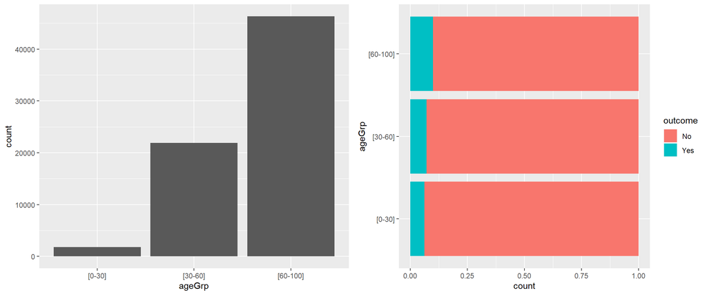

```r
p1 <- data %>%
  ggplot(aes(x = ageGrp)) +
  geom_bar()
p2 <- data %>%
  ggplot(aes(x = ageGrp, fill = outcome)) +
  geom_bar(position = 'fill') +
  coord_flip()
grid.arrange(p1, p2, ncol = 2)
```

#### Time in Hospital

This is the number of days a patient spent in the hospital. The distribution is at max at 3 days, then tails off at the time increases. Maximum observed value is 14 days.

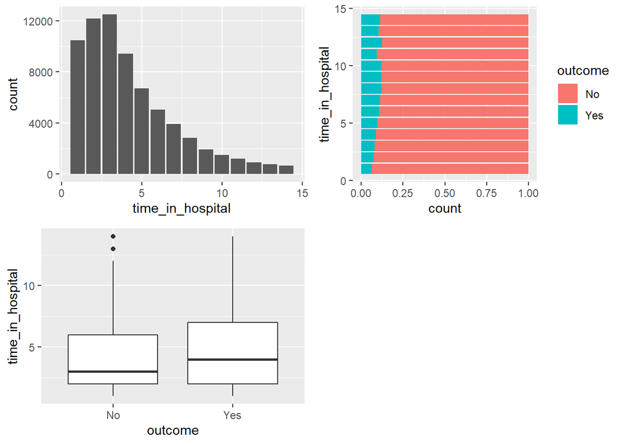

```r
p1 <- data %>%
  ggplot(aes(x = time_in_hospital)) +
  geom_bar()
p2 <- data %>%
  ggplot(aes(x = time_in_hospital, fill = outcome)) +
  geom_bar(position = 'fill') +
  coord_flip()
p3 <- data %>%
  ggplot(aes(x = outcome, y = time_in_hospital)) +
  geom_boxplot()
grid.arrange(p1, p2, p3, ncol = 2)
```

#### Number of Diagnoses

There seem to be a correlation between readmittance and number of diagnoses.

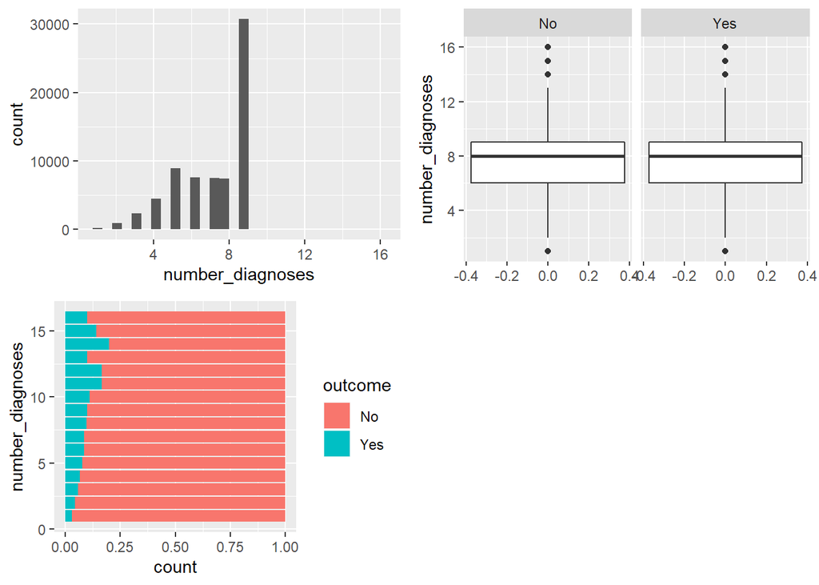

```r
p1 <- data %>%
  ggplot(aes(x = number_diagnoses)) +
  geom_histogram(bins = 30)
p2 <- data %>%
  ggplot(aes(y = number_diagnoses)) +
  geom_boxplot() +
  facet_wrap(. ~ outcome)
p3 <- data %>%
  ggplot(aes(x = number_diagnoses, fill = outcome)) +
  geom_bar(position = 'fill') +
  coord_flip()
grid.arrange(p1, p2, p3, ncol = 2)
```

#### Race vs. Readmission

```r
# readmission within 30 days

#readmission_vs_race <- table(data$outcome,data$race)

#barplot(readmission_vs_race,col=c("#009E73","#D55E00"), legend = rownames(readmission_vs_race), xlab = "Race", #ylab="Diabetic Patient Number", main= "Re-admission within 30 days vs Race")
```

## Modeling

Let’s try some different modeling options. Since we have an imbalanced data set, there are different things we can try. Let’s start with down sampling.

### Down Sample

```r
set.seed(9560)

trainIdx <- createDataPartition(data$outcome, p =.75, list = F, times = 1)
train <- data[trainIdx, ]
test <- data[-trainIdx, ]

set.seed(9560)
train <- downSample(x = train[, -ncol(train)],
                    y = train$outcome, yname="outcome")

train.y = train$outcome
train.x = train[,-ncol(train)]

test.y = test$outcome
test.x = test[,-ncol(test)]
```

### Random Forest Example

https://machinelearningmastery.com/tune-machine-learning-algorithms-in-r/

Training Set

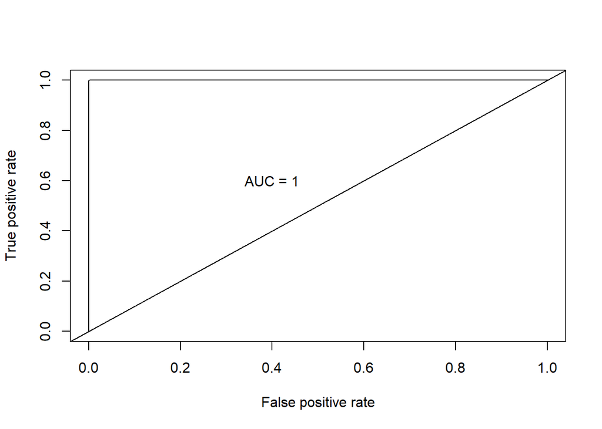

```r
train.rf<-randomForest(outcome~.,data=train,importance=T)
fit.pred<-predict(train.rf,newdata=train,type="prob")

pred <- prediction(fit.pred[,2], train$outcome)
roc.perf = performance(pred, measure = "tpr", x.measure = "fpr")
auc.train <- performance(pred, measure = "auc")
auc.train <- auc.train@y.values
plot(roc.perf)
abline(a=0, b= 1)
text(x = .40, y = .6,paste("AUC = ", round(auc.train[[1]],3), sep = ""))
```

Test Set

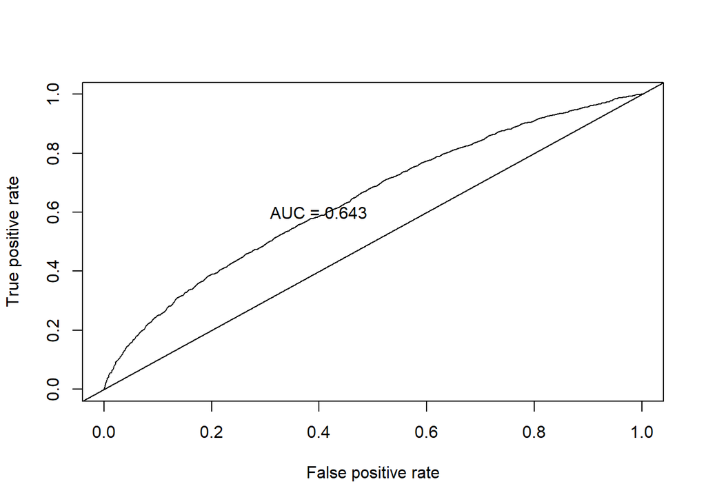

```r
pred.val1<-predict(train.rf,newdata=test,type="prob")
pred <- prediction(pred.val1[,2], test$outcome)
roc.perf = performance(pred, measure = "tpr", x.measure = "fpr")
auc.test <- performance(pred, measure = "auc")
auc.test <- auc.test@y.values
plot(roc.perf)
abline(a=0, b=1)
text(x = .4, y = .6,paste("AUC = ", round(auc.test[[1]],3), sep = ""))
```

**Gini importances plot**

Gini has to do with the cross-entroy of the trees from a split. Decreases in Gini index are desirable.

https://towardsdatascience.com/seeing-the-random-forest-from-the-decision-trees-an-intuitive-explanation-of-random-forest-beaa2d6a0d80

ISL p.312

https://stats.stackexchange.com/questions/92419/relative-importance-of-a-set-of-predictors-in-a-random-forests-classification-in

```r
importance(train.rf)
```

```
##                                   No          Yes MeanDecreaseAccuracy
## race                      2.23980255 -2.068733261           0.21033802
## gender                   -0.52831462 -1.363145114          -1.33226976
## admission_type_id         6.04350602 -0.526235757           4.30960120
## discharge_disposition_id 40.38845854 20.459262774          41.42851654
## admission_source_id      10.89110255 -6.007331426           4.03485428
## time_in_hospital         13.87707923 -3.042581279           8.65823739
## num_lab_procedures       11.86892372 -5.109227443           5.32193179
## num_procedures            2.91554844  1.551301496           3.31083120
## num_medications           5.06199155  0.053208829           4.08496831
## number_outpatient         0.02378279  0.279343557           0.22298545
## number_emergency          5.77318011  3.867377003           6.78935125
## number_inpatient         22.83523149 16.842970643          27.53622763
## diag_1                    4.31526854  3.246470142           5.69989812
## diag_2                    3.66708857  0.213025681           2.82033993
## diag_3                    6.69021292 -4.033837082           1.96237239
## number_diagnoses         10.64947071 -2.330703121           6.70178772
## max_glu_serum             2.44708421 -0.909922251           1.14929676
## A1Cresult                 3.43510199  0.006188106           2.80390425
## metformin                 2.51264610 -0.918299572           1.37928788
## repaglinide               1.05336972 -0.404609834           0.44440575
## nateglinide               0.46936449 -0.828681963          -0.17825915
## chlorpropamide            1.85072784 -0.733512718           1.05281785
## glimepiride               1.45516605 -4.964348174          -2.49185481
## acetohexamide             0.00000000  0.000000000           0.00000000
## glipizide                 2.97491394 -1.771278009           0.83482033
## glyburide                -1.07300249 -0.986215277          -1.53838508
## tolbutamide               0.00000000  0.000000000           0.00000000
## pioglitazone              1.28628310 -1.297706034          -0.01296378
## rosiglitazone            -0.64863130 -1.506938625          -1.55733910
## acarbose                  1.37468629  0.446051994           1.30369601
## miglitol                  0.00000000  0.000000000           0.00000000
## troglitazone              0.00000000  0.000000000           0.00000000
## tolazamide                0.00000000  0.000000000           0.00000000
## insulin                   3.58991062 -1.719548760           1.39665426
## glyburide.metformin       1.73162743  0.990609622           1.96371486
## glipizide.metformin       0.00000000  0.000000000           0.00000000
## glimepiride.pioglitazone  0.00000000  0.000000000           0.00000000
## metformin.rosiglitazone   0.00000000  0.000000000           0.00000000
## metformin.pioglitazone    0.00000000  0.000000000           0.00000000
```

[output cut: 31 more lines]

```
## pioglitazone                  39.94835511
## rosiglitazone                 39.57770232
## acarbose                       2.77165100
## miglitol                       0.00000000
## troglitazone                   0.00000000
## tolazamide                     0.22910124
## insulin                      151.63949754
## glyburide.metformin            6.60618930
## glipizide.metformin            0.28016164
## glimepiride.pioglitazone       0.00000000
## metformin.rosiglitazone        0.00000000
## metformin.pioglitazone         0.00000000
## change                        59.57850232
## diabetesMed                   47.24643622
## ageGrp                        72.96096316
```

```r
rf.feature.importance <- data.frame(importance(train.rf))

varimp1 <- rf.feature.importance[order(rf.feature.importance$MeanDecreaseGini,decreasing = T),]

varimp1
```

```
##                                   No          Yes MeanDecreaseAccuracy
## num_lab_procedures       11.86892372 -5.109227443           5.32193179
## num_medications           5.06199155  0.053208829           4.08496831
## diag_3                    6.69021292 -4.033837082           1.96237239
## diag_1                    4.31526854  3.246470142           5.69989812
## diag_2                    3.66708857  0.213025681           2.82033993
## discharge_disposition_id 40.38845854 20.459262774          41.42851654
## time_in_hospital         13.87707923 -3.042581279           8.65823739
## number_diagnoses         10.64947071 -2.330703121           6.70178772
## num_procedures            2.91554844  1.551301496           3.31083120
## admission_type_id         6.04350602 -0.526235757           4.30960120
## admission_source_id      10.89110255 -6.007331426           4.03485428
## insulin                   3.58991062 -1.719548760           1.39665426
## race                      2.23980255 -2.068733261           0.21033802
## number_inpatient         22.83523149 16.842970643          27.53622763
## A1Cresult                 3.43510199  0.006188106           2.80390425
## number_outpatient         0.02378279  0.279343557           0.22298545
## gender                   -0.52831462 -1.363145114          -1.33226976
## ageGrp                   10.15445024 -0.094423805           7.97049779
## metformin                 2.51264610 -0.918299572           1.37928788
## glipizide                 2.97491394 -1.771278009           0.83482033
## change                    2.59495119 -2.203857982           0.32069966
## glyburide                -1.07300249 -0.986215277          -1.53838508
## number_emergency          5.77318011  3.867377003           6.78935125
## diabetesMed               6.80220516 -1.771667263           4.12616579
## pioglitazone              1.28628310 -1.297706034          -0.01296378
## rosiglitazone            -0.64863130 -1.506938625          -1.55733910
## max_glu_serum             2.44708421 -0.909922251           1.14929676
## glimepiride               1.45516605 -4.964348174          -2.49185481
## repaglinide               1.05336972 -0.404609834           0.44440575
## glyburide.metformin       1.73162743  0.990609622           1.96371486
## nateglinide               0.46936449 -0.828681963          -0.17825915
## acarbose                  1.37468629  0.446051994           1.30369601
## chlorpropamide            1.85072784 -0.733512718           1.05281785
## glipizide.metformin       0.00000000  0.000000000           0.00000000
## tolazamide                0.00000000  0.000000000           0.00000000
## tolbutamide               0.00000000  0.000000000           0.00000000
## acetohexamide             0.00000000  0.000000000           0.00000000
## miglitol                  0.00000000  0.000000000           0.00000000
## troglitazone              0.00000000  0.000000000           0.00000000
```

[output cut: 31 more lines]

```
## glimepiride                   34.12566946
## repaglinide                   13.24125733
## glyburide.metformin            6.60618930
## nateglinide                    6.29103734
## acarbose                       2.77165100
## chlorpropamide                 1.17329359
## glipizide.metformin            0.28016164
## tolazamide                     0.22910124
## tolbutamide                    0.02874514
## acetohexamide                  0.00000000
## miglitol                       0.00000000
## troglitazone                   0.00000000
## glimepiride.pioglitazone       0.00000000
## metformin.rosiglitazone        0.00000000
## metformin.pioglitazone         0.00000000
```

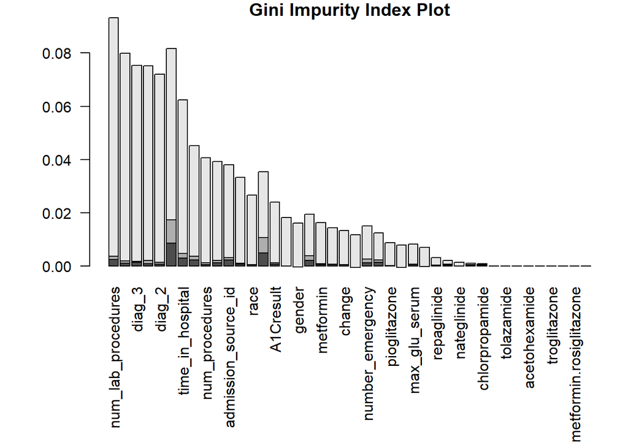

```r
par(mar=c(10,5,1,1))
giniplot <- barplot(t(varimp1[-2]/sum(varimp1[-2])), las=2, cex.names=1,
                    main="Gini Impurity Index Plot")
```

Sampling Tuning Test

```r
bestmtry <- tuneRF(train.x, train.y, stepFactor=.5, improve=1e-5, ntree=500)
```

```
## mtry = 6  OOB error = 40.04%
## Searching left ...
## mtry = 12    OOB error = 40.02%
## 0.0005298013 1e-05
## mtry = 24    OOB error = 39.68%
## 0.008481315 1e-05
```

```
## mtry = 48    OOB error = 41.03%
## -0.03394814 1e-05
## Searching right ...
## mtry = 3     OOB error = 39.39%
## 0.007217322 1e-05
## mtry = 1     OOB error = 42%
## -0.06623586 1e-05
```

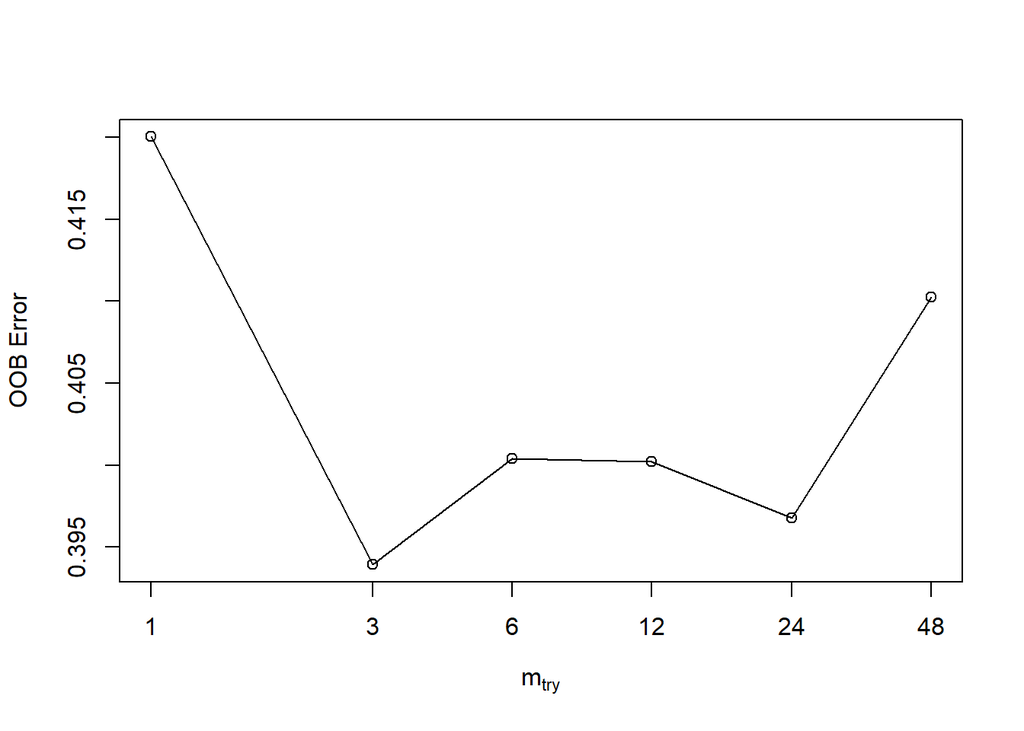

```r
print(bestmtry)
```

```
##        mtry  OOBError
## 1.OOB     1 0.4200255
## 3.OOB     3 0.3939330
## 6.OOB     6 0.4004031
## 12.OOB   12 0.4001909
## 24.OOB   24 0.3967968
## 48.OOB   48 0.4102673
```

### Simple Logistic Example

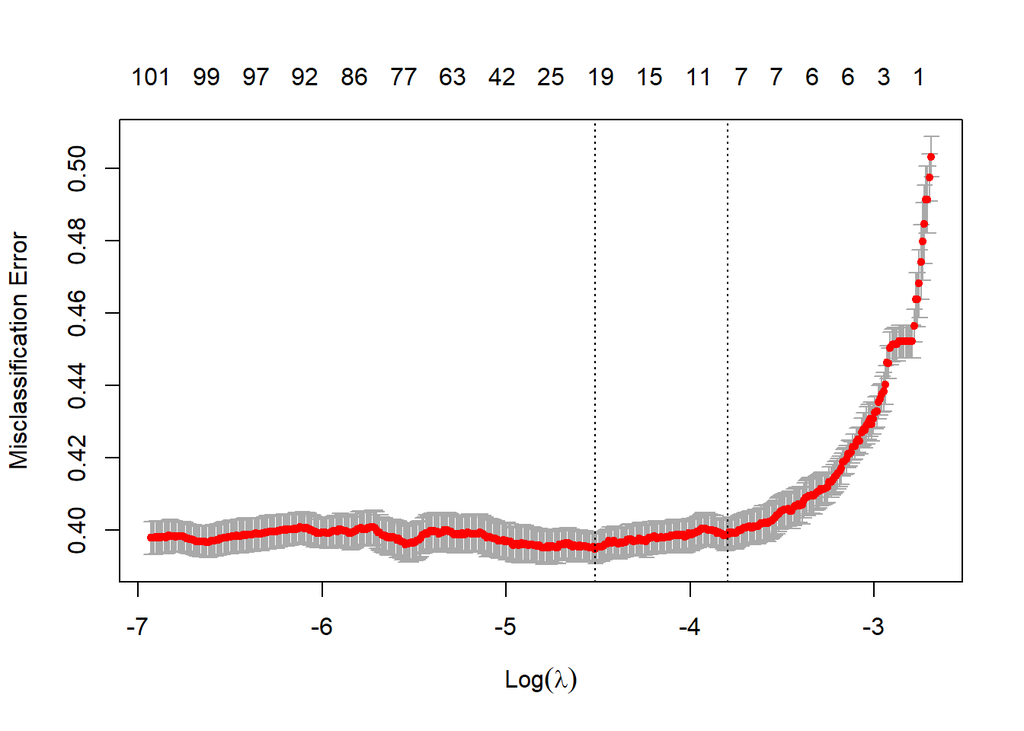

```r
#glmnet requires a matrix
set.seed(9560)
f <- as.formula(outcome ~ .)
train.x <- model.matrix(f, train)
#train.x <- data.matrix(train.x)
cvfit <- cv.glmnet(train.x,train.y, family = "binomial", type.measure = "class", nlambda = 1000)
plot(cvfit)
```

```r
coef(cvfit, s = "lambda.min")
```

```
## 146 x 1 sparse Matrix of class "dgCMatrix"
##                                            1
## (Intercept)                    -0.8991107184
## (Intercept)                     .
## raceAfricanAmerican             .
## raceAsian                       .
## raceCaucasian                   .
## raceHispanic                    .
## raceOther                       .
## raceMissing                     .
## genderMale                      .
## genderUnknown/Invalid           .
## admission_type_id2              .
## admission_type_id3              .
## admission_type_id4              .
## admission_type_id5              .
## admission_type_id6              .
## admission_type_id7              .
## admission_type_id8              .
## discharge_disposition_id2       0.1120920268
## discharge_disposition_id3       0.3575119874
## discharge_disposition_id4       .
## discharge_disposition_id5       0.6935424724
## discharge_disposition_id6       .
## discharge_disposition_id7       .
## discharge_disposition_id8       .
## discharge_disposition_id9       .
## discharge_disposition_id10      .
## discharge_disposition_id12      .
## discharge_disposition_id15      0.4991803372
## discharge_disposition_id16      .
## discharge_disposition_id17      .
## discharge_disposition_id18      0.1017739261
## discharge_disposition_id22      1.0498319714
## discharge_disposition_id23      .
## discharge_disposition_id24      .
## discharge_disposition_id25      .
## discharge_disposition_id27      .
## discharge_disposition_id28      0.7040133949
## admission_source_id2            .
```

[output cut: 93 more lines]

```
## tolazamideUp                    .
## insulinNo                       .
## insulinSteady                   .
## insulinUp                       .
## glyburide.metforminNo           .
## glyburide.metforminSteady       .
## glyburide.metforminUp           .
## glipizide.metforminSteady       .
## glimepiride.pioglitazoneSteady  .
## metformin.rosiglitazoneSteady   .
## metformin.pioglitazoneSteady    .
## changeNo                        .
## diabetesMedYes                  0.1190299992
## ageGrp[30-60]                   .
## ageGrp[60-100]                  0.1955542793
```

```r
#rownames(coef(cvfit, s = 'lambda.min'))[coef(cvfit, s = 'lambda.min')[,1]!=0]

#Get training set predictions...We know they are biased but lets create ROC's.
#These are predicted probabilities from logistic model  exp(b)/(1+exp(b))
fit.pred <- predict(cvfit, newx = train.x, type = "response")

#Compare the prediction to the real outcome
head(fit.pred)
```

```
##           1
## 1 0.4413424
## 2 0.4745332
## 3 0.5443025
## 4 0.4162065
## 5 0.4810746
## 6 0.4891101
```

```r
head(train.y)
```

```
## [1] No No No No No No
## Levels: No Yes
```

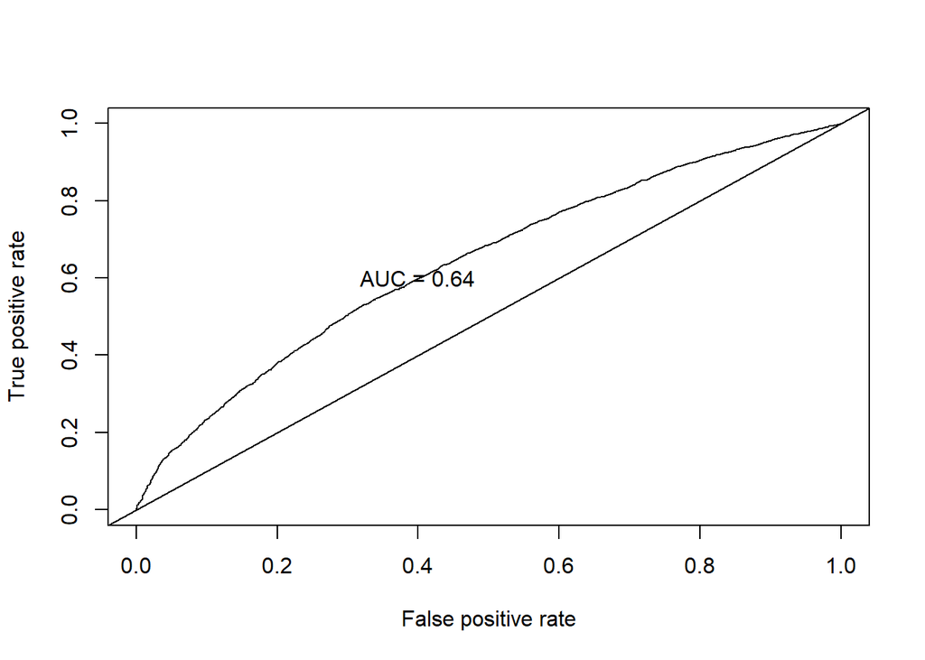

```r
#Create ROC curves
pred <- prediction(fit.pred[,1], train.y)
roc.perf = performance(pred, measure = "tpr", x.measure = "fpr")
auc.train <- performance(pred, measure = "auc")
auc.train <- auc.train@y.values

#Plot ROC
plot(roc.perf)
abline(a=0, b= 1) #Ref line indicating poor performance
text(x = .40, y = .6,paste("AUC = ", round(auc.train[[1]],3), sep = ""))
```

Take the coefficients from above, and create a glm model using them since glmnet/lasso will bias the coefficients towards zero. Note, each time I restart R, I get a different set of coefficients for the same seed value??

```r
f <- as.formula(outcome ~ discharge_disposition_id + time_in_hospital + num_lab_procedures + num_medications + number_emergency + number_inpatient + diag_1 + diag_2 + number_diagnoses + metformin + diabetesMed + ageGrp)

#f <- as.formula(outcome ~ discharge_disposition_id + number_inpatient + diag_1)

glm.simple <- glm(formula = f, family = "binomial", data = train)
coef(glm.simple)
```

```
##                (Intercept)  discharge_disposition_id2
##               -1.156577901                0.443516035
##  discharge_disposition_id3  discharge_disposition_id4
##                0.617525695                0.371623590
##  discharge_disposition_id5  discharge_disposition_id6
##                1.212206738                0.178116867
##  discharge_disposition_id7  discharge_disposition_id8
##                0.267792743                0.875968919
##  discharge_disposition_id9 discharge_disposition_id10
##                0.243741029              -12.216850234
## discharge_disposition_id12 discharge_disposition_id15
##               12.806130273                2.720753002
## discharge_disposition_id16 discharge_disposition_id18
##              -11.784945370                0.502136234
## discharge_disposition_id22 discharge_disposition_id23
##                1.543457573               -0.489293303
## discharge_disposition_id24 discharge_disposition_id25
##              -12.239257091                0.028039653
## discharge_disposition_id28           time_in_hospital
##                1.806982542                0.016097981
##         num_lab_procedures            num_medications
##                0.002281764                0.004789978
##           number_emergency           number_inpatient
##                0.185229815                0.385936365
##             diag_1Diabetes            diag_1Digestive
##                0.078237891               -0.060139978
##        diag_1Genitourinary               diag_1Injury
##               -0.161596544               -0.265017162
##      diag_1Musculoskeletal            diag_1Neoplasms
##               -0.378324548               -0.133677213
##                 diag_1None                diag_1Other
##               -0.337600064                0.067752414
##          diag_1Respiratory             diag_2Diabetes
##               -0.256543568                0.143304900
##            diag_2Digestive        diag_2Genitourinary
##                0.067357697               -0.075998831
##               diag_2Injury      diag_2Musculoskeletal
##                0.176743132               -0.137123891
##            diag_2Neoplasms                 diag_2None
##                0.082414974                0.199119810
##                diag_2Other          diag_2Respiratory
##               -0.201551271               -0.082642713
##           number_diagnoses                metforminNo
##                0.056919614               -0.234158787
##            metforminSteady                metforminUp
##               -0.394045821               -0.419700206
##             diabetesMedYes              ageGrp[30-60]
##                0.251700402                0.113769086
##             ageGrp[60-100]
##                0.381034015
```

```r
#Get training set predictions...We know they are biased but lets create ROC's.
#These are predicted probabilities from logistic model  exp(b)/(1+exp(b))
fit.pred <- predict(glm.simple, newx = train.x, type = "response")

#Compare the prediction to the real outcome
head(fit.pred)
```

```
##         1         2         3         4         5         6
## 0.4515408 0.4669324 0.5162197 0.3860540 0.3855658 0.4780526
```

```r
head(train.y)
```

```
## [1] No No No No No No
## Levels: No Yes
```

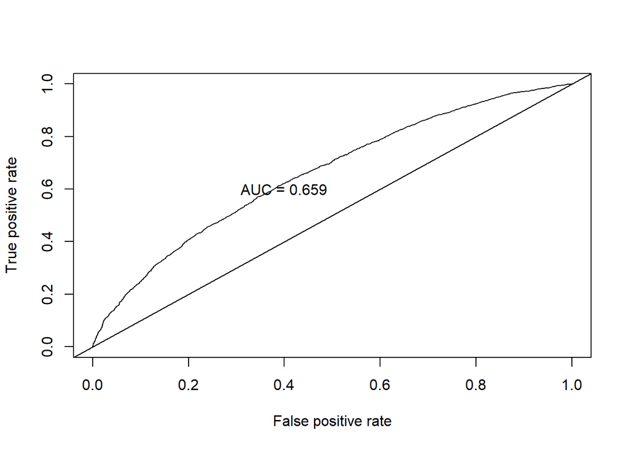

```r
#Create ROC curves
pred <- prediction(fit.pred, train.y)
roc.perf = performance(pred, measure = "tpr", x.measure = "fpr")
auc.train <- performance(pred, measure = "auc")
auc.train <- auc.train@y.values

#Plot ROC
plot(roc.perf)
abline(a=0, b= 1) #Ref line indicating poor performance
text(x = .40, y = .6,paste("AUC = ", round(auc.train[[1]],3), sep = ""))
```

Stole the function from stack overflow. I think in general this will always be an issue. Missing factor levels between test and train sets. https://stackoverflow.com/questions/4285214/predict-lm-with-an-unknown-factor-level-in-test-data

```r
remove_missing_levels <- function(fit, test_data) {

  # https://stackoverflow.com/a/39495480/4185785

  # drop empty factor levels in test data
  test_data %>%
    droplevels() %>%
    as.data.frame() -> test_data

  # 'fit' object structure of 'lm' and 'glmmPQL' is different so we need to
  # account for it
  if (any(class(fit) == "glmmPQL")) {
    # Obtain factor predictors in the model and their levels
    factors <- (gsub("[-^0-9]|as.factor|\\(|\\)", "",
                     names(unlist(fit$contrasts))))
    # do nothing if no factors are present
    if (length(factors) == 0) {
      return(test_data)
    }

    map(fit$contrasts, function(x) names(unmatrix(x))) %>%
      unlist() -> factor_levels
    factor_levels %>% str_split(":", simplify = TRUE) %>%
      extract(, 1) -> factor_levels

    model_factors <- as.data.frame(cbind(factors, factor_levels))
  } else {
    # Obtain factor predictors in the model and their levels
    factors <- (gsub("[-^0-9]|as.factor|\\(|\\)", "",
                     names(unlist(fit$xlevels))))
    # do nothing if no factors are present
    if (length(factors) == 0) {
      return(test_data)
    }

    factor_levels <- unname(unlist(fit$xlevels))
    model_factors <- as.data.frame(cbind(factors, factor_levels))
  }

  # Select column names in test data that are factor predictors in
  # trained model

  predictors <- names(test_data[names(test_data) %in% factors])

  # For each factor predictor in your data, if the level is not in the model,
  # set the value to NA

  for (i in 1:length(predictors)) {
    found <- test_data[, predictors[i]] %in% model_factors[
      model_factors$factors == predictors[i], ]$factor_levels
    if (any(!found)) {
      # track which variable
      var <- predictors[i]
      # set to NA
      test_data[!found, predictors[i]] <- NA
      # drop empty factor levels in test data
      test_data %>%
        droplevels() -> test_data
      # issue warning to console
      message(sprintf(paste0("Setting missing levels in '%s', only present",
                             " in test data but missing in train data,",
                             " to 'NA'."),
                      var))
    }
  }
  return(test_data)
}
```

Run model against test set, using simple fit, no interaction. Use the model created above. Run against test data set and remove missing levels, otherwise, predict will fail if there are levels in test that weren’t encountered in train.

```r
#Run model from training set on test set
set.seed(9560)
fit.pred1 <- predict(glm.simple, newdata = remove_missing_levels(fit=glm.simple, test_data = test), type = "response")
```

```
## Setting missing levels in 'discharge_disposition_id', only present in test data but missing in train data, to 'NA'.
```

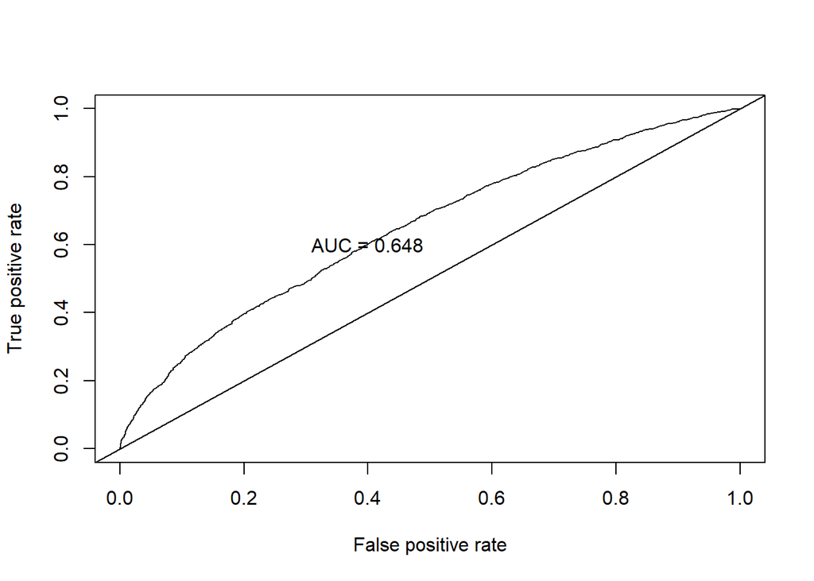

```r
#ROC curves
pred1 <- prediction(fit.pred1, test.y)
roc.perf1 = performance(pred1, measure = "tpr", x.measure = "fpr")
auc.val1 <- performance(pred1, measure = "auc")
auc.val1 <- auc.val1@y.values
plot(roc.perf1)
abline(a=0, b= 1)
text(x = .40, y = .6,paste("AUC = ", round(auc.val1[[1]],3), sep = ""))
```

### Desiscion Tree

We’ll need to use a more balanced data set for a decsion tree. Running against the original data set returns nothing. So used the train set created by down sampling.

```r
par(mfrow=c(1,1))
thetree <- tree(outcome ~ ., data = train, mincut=5)
summary(thetree)
```

```
##
## Classification tree:
## tree(formula = outcome ~ ., data = train, mincut = 5)
## Variables actually used in tree construction:
## [1] "discharge_disposition_id" "number_inpatient"
## Number of terminal nodes:  3
## Residual mean deviance:  1.344 = 12660 / 9425
## Misclassification error rate: 0.4015 = 3785 / 9428
```

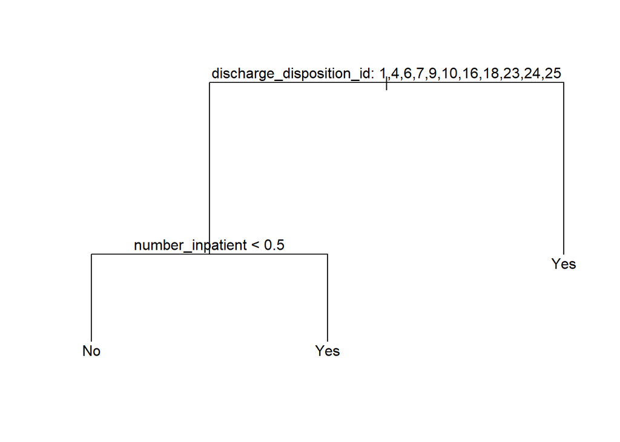

```r
plot(thetree)
text(thetree,pretty=0)
```

Let’s create a glm model using just the predictors above from decision tree, and see how it compares.

```r
f <- as.formula(outcome ~ discharge_disposition_id + number_inpatient)

glm.tree <- glm(formula = f, family = "binomial", data = train)
coef(glm.tree)
```

```
##                (Intercept)  discharge_disposition_id2
##                -0.37491339                 0.52475894
##  discharge_disposition_id3  discharge_disposition_id4
##                 0.72508732                 0.46432500
##  discharge_disposition_id5  discharge_disposition_id6
##                 1.23396386                 0.30396669
##  discharge_disposition_id7  discharge_disposition_id8
##                 0.18090323                 0.83419365
##  discharge_disposition_id9 discharge_disposition_id10
##                 0.26641890               -12.62772005
## discharge_disposition_id12 discharge_disposition_id15
##                12.94097640                 2.77803950
## discharge_disposition_id16 discharge_disposition_id18
##               -12.19114961                 0.48078739
## discharge_disposition_id22 discharge_disposition_id23
##                 1.61219406                -0.28995222
## discharge_disposition_id24 discharge_disposition_id25
##               -12.19114961                 0.04192367
## discharge_disposition_id28           number_inpatient
##                 1.80001999                 0.43657043
```

```r
#Get training set predictions...We know they are biased but lets create ROC's.
#These are predicted probabilities from logistic model  exp(b)/(1+exp(b))
fit.pred <- predict(glm.tree, newx = train.x, type = "response")

#Compare the prediction to the real outcome
head(fit.pred)
```

```
##         1         2         3         4         5         6
## 0.5373914 0.4516490 0.5904011 0.4073543 0.4822708 0.4073543
```

```r
head(train.y)
```

```
## [1] No No No No No No
## Levels: No Yes
```

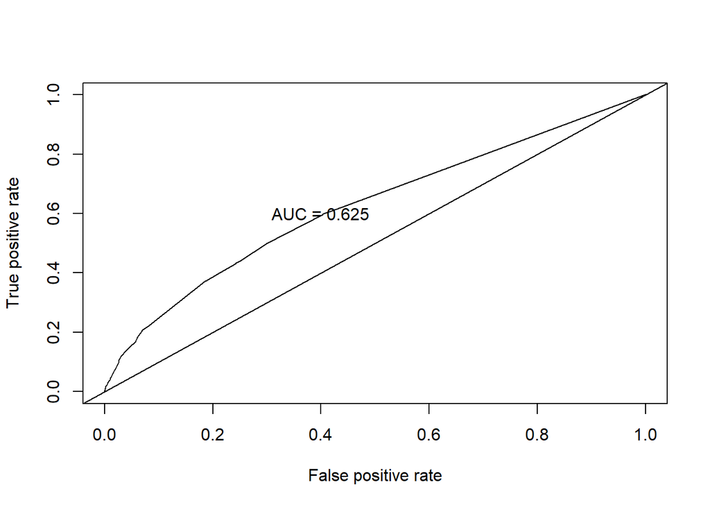

```r
#Create ROC curves
pred <- prediction(fit.pred, train.y)
roc.perf = performance(pred, measure = "tpr", x.measure = "fpr")
auc.train <- performance(pred, measure = "auc")
auc.train <- auc.train@y.values

#Plot ROC
plot(roc.perf)
abline(a=0, b= 1) #Ref line indicating poor performance
text(x = .40, y = .6,paste("AUC = ", round(auc.train[[1]],3), sep = ""))
```

Now apply it against test set

```r
#Run model from descision tree predictors
set.seed(9560)
fit.pred.tree <- predict(glm.tree, newdata = remove_missing_levels(fit=glm.tree, test_data = test), type = "response")
```

```
## Setting missing levels in 'discharge_disposition_id', only present in test data but missing in train data, to 'NA'.
```

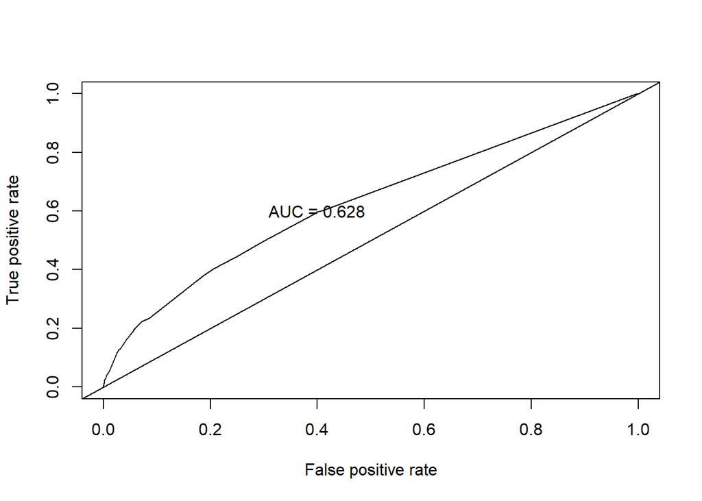

```r
#ROC curves
pred.tree <- prediction(fit.pred.tree, test.y)
roc.perf.tree = performance(pred.tree, measure = "tpr", x.measure = "fpr")
auc.val.tree <- performance(pred.tree, measure = "auc")
auc.val.tree <- auc.val.tree@y.values
plot(roc.perf.tree)
abline(a=0, b= 1)
text(x = .40, y = .6,paste("AUC = ", round(auc.val.tree[[1]],3), sep = ""))
```

### Complex Logistic Example, Let’s include sqrt of number_inpatient

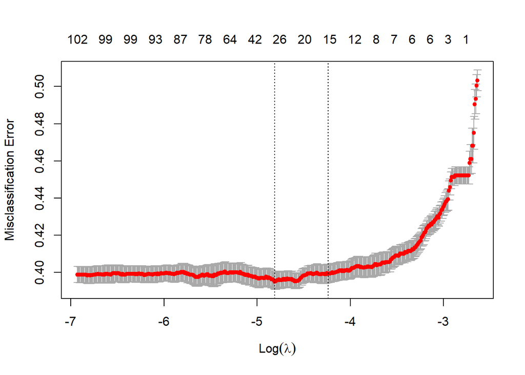

```r
#glmnet requires a matrix
set.seed(9560)
f <- as.formula(outcome ~ . + I(number_inpatient^.5))
train.x <- model.matrix(f, train)
cvfit <- cv.glmnet(train.x,train.y, family = "binomial", type.measure = "class", nlambda = 1000)
plot(cvfit)
```

```r
coef(cvfit, s = "lambda.min")
```

```
## 147 x 1 sparse Matrix of class "dgCMatrix"
##                                           1
## (Intercept)                    -1.000594685
## (Intercept)                     .
## raceAfricanAmerican             .
## raceAsian                       .
## raceCaucasian                   .
## raceHispanic                    .
## raceOther                      -0.012154466
## raceMissing                     .
## genderMale                      .
## genderUnknown/Invalid           .
## admission_type_id2              .
## admission_type_id3              .
## admission_type_id4              .
## admission_type_id5              .
## admission_type_id6              .
## admission_type_id7             -0.266547709
## admission_type_id8              .
## discharge_disposition_id2       0.180746387
## discharge_disposition_id3       0.405859505
## discharge_disposition_id4       .
## discharge_disposition_id5       0.802907250
## discharge_disposition_id6       .
## discharge_disposition_id7       .
## discharge_disposition_id8       .
## discharge_disposition_id9       .
## discharge_disposition_id10      .
## discharge_disposition_id12      .
## discharge_disposition_id15      0.856843793
## discharge_disposition_id16      .
## discharge_disposition_id17      .
## discharge_disposition_id18      0.200939360
## discharge_disposition_id22      1.156251121
## discharge_disposition_id23      .
## discharge_disposition_id24      .
## discharge_disposition_id25      .
## discharge_disposition_id27      .
## discharge_disposition_id28      0.946775114
## admission_source_id2            .
```

[output cut: 94 more lines]

```
## insulinNo                       .
## insulinSteady                   .
## insulinUp                       .
## glyburide.metforminNo           .
## glyburide.metforminSteady       .
## glyburide.metforminUp           .
## glipizide.metforminSteady       .
## glimepiride.pioglitazoneSteady  .
## metformin.rosiglitazoneSteady   .
## metformin.pioglitazoneSteady    .
## changeNo                        .
## diabetesMedYes                  0.154243548
## ageGrp[30-60]                   .
## ageGrp[60-100]                  0.208662001
## I(number_inpatient^0.5)         0.394754648
```

```r
#rownames(coef(cvfit, s = 'lambda.min'))[coef(cvfit, s = 'lambda.min')[,1]!=0]

#Get training set predictions...We know they are biased but lets create ROC's.
#These are predicted probabilities from logistic model  exp(b)/(1+exp(b))
fit.pred <- predict(cvfit, newx = train.x, type = "response")

#Compare the prediction to the real outcome
head(fit.pred)
```

```
##           1
## 1 0.4253312
## 2 0.4612374
## 3 0.5643318
## 4 0.3938964
## 5 0.4520642
## 6 0.4846675
```

```r
head(train.y)
```

```
## [1] No No No No No No
## Levels: No Yes
```

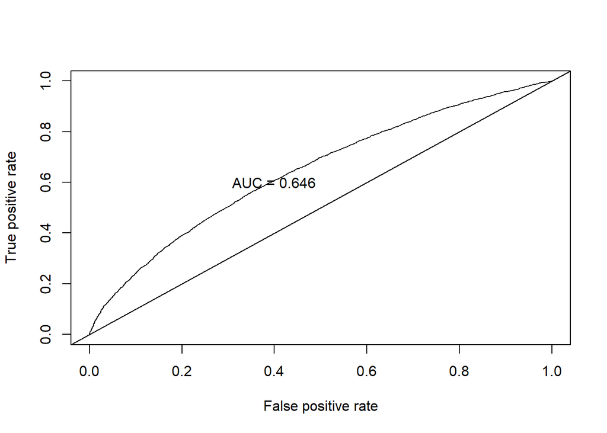

```r
#Create ROC curves
pred <- prediction(fit.pred[,1], train.y)
roc.perf = performance(pred, measure = "tpr", x.measure = "fpr")
auc.train <- performance(pred, measure = "auc")
auc.train <- auc.train@y.values

#Plot ROC
plot(roc.perf)
abline(a=0, b= 1) #Ref line indicating poor performance
text(x = .40, y = .6,paste("AUC = ", round(auc.train[[1]],3), sep = ""))
```

Now use coefficients determined above, create a new formula and create complex model

```r
f <- as.formula(outcome ~ race + admission_type_id + discharge_disposition_id + admission_source_id + time_in_hospital + num_lab_procedures + num_medications + number_emergency + number_inpatient + diag_1 + diag_2 + diag_3 + number_diagnoses + A1Cresult + metformin + glimepiride + acarbose + diabetesMed + ageGrp + I(number_inpatient^.5))

glm.complex <- glm(formula = f, family = "binomial", data = train)
coef(glm.complex)
```

```
##                (Intercept)                  raceAsian
##               -1.118589422               -0.318730210
##              raceCaucasian               raceHispanic
##               -0.096295699                0.053627610
##                  raceOther                raceMissing
##               -0.351452355               -0.259084544
##         admission_type_id2         admission_type_id3
##               -0.002664398               -0.057906825
##         admission_type_id4         admission_type_id5
##               13.335012631                0.004735921
##         admission_type_id6         admission_type_id7
##                0.193735377              -13.629011801
##         admission_type_id8  discharge_disposition_id2
##                0.143561941                0.464001019
##  discharge_disposition_id3  discharge_disposition_id4
##                0.651677910                0.405378625
##  discharge_disposition_id5  discharge_disposition_id6
##                1.235769381                0.181267225
##  discharge_disposition_id7  discharge_disposition_id8
##                0.321799843                0.847916762
##  discharge_disposition_id9 discharge_disposition_id10
##                0.153508298              -13.558383281
## discharge_disposition_id12 discharge_disposition_id15
##               13.699735989                2.694243392
## discharge_disposition_id16 discharge_disposition_id18
##              -12.731333501                0.529963187
## discharge_disposition_id22 discharge_disposition_id23
##                1.557868932               -0.483841969
## discharge_disposition_id24 discharge_disposition_id25
##              -13.370189251               -0.122692043
## discharge_disposition_id28       admission_source_id2
##                1.819003184               -0.125809868
##       admission_source_id3       admission_source_id4
##                0.374295958               -0.042015105
##       admission_source_id5       admission_source_id6
##               -0.760303901               -0.118218291
##       admission_source_id7       admission_source_id8
##               -0.090491583              -13.482005531
##       admission_source_id9      admission_source_id17
##                0.174916404               -0.214229328
```

[output cut: 35 more lines]

```
##                0.065952644                0.170892620
##              A1CresultNone              A1CresultNorm
##                0.238548987                0.031256621
##                metforminNo            metforminSteady
##               -0.226812842               -0.379802289
##                metforminUp              glimepirideNo
##               -0.356802799               -0.227352990
##          glimepirideSteady              glimepirideUp
##               -0.383144512                0.418968254
##             acarboseSteady                 acarboseUp
##               -0.871335054               13.296677103
##             diabetesMedYes              ageGrp[30-60]
##                0.269047378                0.087963573
##             ageGrp[60-100]    I(number_inpatient^0.5)
##                0.365462381                0.347090565
```

```r
#Get training set predictions...We know they are biased but lets create ROC's.
#These are predicted probabilities from logistic model  exp(b)/(1+exp(b))
fit.pred <- predict(glm.complex, newx = train.x, type = "response")

#Compare the prediction to the real outcome
head(fit.pred)
```

```
##         1         2         3         4         5         6
## 0.4181937 0.4031593 0.5448609 0.4281873 0.3942556 0.4770023
```

```r
head(train.y)
```

```
## [1] No No No No No No
## Levels: No Yes
```

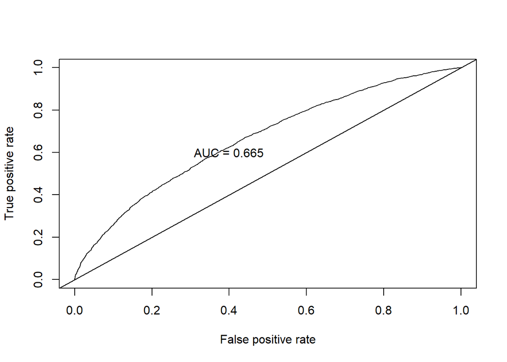

```r
#Create ROC curves
pred <- prediction(fit.pred, train.y)
roc.perf = performance(pred, measure = "tpr", x.measure = "fpr")
auc.train <- performance(pred, measure = "auc")
auc.train <- auc.train@y.values

#Plot ROC
plot(roc.perf)
abline(a=0, b= 1) #Ref line indicating poor performance
text(x = .40, y = .6,paste("AUC = ", round(auc.train[[1]],3), sep = ""))
```

```r
#Run model from complex train on test
set.seed(9560)
fit.pred.complex <- predict(glm.complex, newdata = remove_missing_levels(fit=glm.complex, test_data = test), type = "response")
```

```
## Setting missing levels in 'discharge_disposition_id', only present in test data but missing in train data, to 'NA'.
```

```
## Setting missing levels in 'admission_source_id', only present in test data but missing in train data, to 'NA'.
```

[figure not shown]

```r
#ROC curves
pred1 <- prediction(fit.pred.complex, test.y)
roc.perf.complex = performance(pred1, measure = "tpr", x.measure = "fpr")
auc.val.complex <- performance(pred1, measure = "auc")
auc.val.complex <- auc.val.complex@y.values
plot(roc.perf.complex)
abline(a=0, b= 1)
text(x = .40, y = .6,paste("AUC = ", round(auc.val1[[1]],3), sep = ""))
```

Notice above we got a better training score with the complext model, we ended up getting a lower score when applying to the test set.

### K-NN

```r
# do lots of 'dummy' transforms for knn because it cannot take factor vars
train2 <- train
test2 <- test
# training data
gender <- as.data.frame(dummy.code(train2$gender))
race <- as.data.frame(dummy.code(train2$race))
admission_type_id <- as.data.frame(dummy.code(train2$admission_type_id))
names(admission_type_id) <- paste('admission_type_id.', names(admission_type_id), sep = '')
discharge_disposition_id <- as.data.frame(dummy.code(train2$discharge_disposition_id))
names(discharge_disposition_id) <- paste('discharge_disposition_id.', names(discharge_disposition_id), sep = '')
admission_source_id <- as.data.frame(dummy.code(train2$admission_source_id))
names(admission_source_id) <- paste('admission_source_id.', names(admission_source_id), sep = '')
diag_1 <- as.data.frame(dummy.code(train2$diag_1))
names(diag_1) <- paste('diag_1.', names(diag_1), sep = '')
diag_2 <- as.data.frame(dummy.code(train2$diag_2))
names(diag_2) <- paste('diag_2.', names(diag_2), sep = '')
diag_3 <- as.data.frame(dummy.code(train2$diag_3))
names(diag_3) <- paste('diag_3.', names(diag_3), sep = '')
max_glu_serum <- as.data.frame(dummy.code(train2$max_glu_serum))
names(max_glu_serum) <- paste('max_glu_serum.', names(max_glu_serum), sep = '')
A1Cresult <- as.data.frame(dummy.code(train2$A1Cresult))
names(A1Cresult) <- paste('A1Cresult.', names(A1Cresult), sep = '')
metformin <- as.data.frame(dummy.code(train2$metformin))
names(metformin) <- paste('metformin.', names(metformin), sep = '')
repaglinide <- as.data.frame(dummy.code(train2$repaglinide))
names(repaglinide) <- paste('repaglinide.', names(repaglinide), sep = '')
nateglinide <- as.data.frame(dummy.code(train2$nateglinide))
names(nateglinide) <- paste('nateglinide.', names(nateglinide), sep = '')
chlorpropamide <- as.data.frame(dummy.code(train2$chlorpropamide))
names(chlorpropamide) <- paste('chlorpropamide.', names(chlorpropamide), sep = '')
glimepiride <- as.data.frame(dummy.code(train2$glimepiride))
names(glimepiride) <- paste('glimepiride.', names(glimepiride), sep = '')
acetohexamide <- as.data.frame(dummy.code(train2$acetohexamide))
names(acetohexamide) <- paste('acetohexamide.', names(acetohexamide), sep = '')
glipizide<- as.data.frame(dummy.code(train2$glipizide))
names(glipizide) <- paste('glipizide.', names(glipizide), sep = '')
glyburide <- as.data.frame(dummy.code(train2$glyburide))
names(glyburide) <- paste('glyburide.', names(glyburide), sep = '')
tolbutamide <- as.data.frame(dummy.code(train2$tolbutamide))
names(tolbutamide) <- paste('tolbutamide.', names(tolbutamide), sep = '')
pioglitazone <- as.data.frame(dummy.code(train2$pioglitazone))
names(pioglitazone) <- paste('pioglitazone.', names(pioglitazone), sep = '')
rosiglitazone <- as.data.frame(dummy.code(train2$rosiglitazone))
names(rosiglitazone) <- paste('rosiglitazone.', names(rosiglitazone), sep = '')
acarbose <- as.data.frame(dummy.code(train2$acarbose))
names(acarbose) <- paste('acarbose.', names(acarbose), sep = '')
miglitol <- as.data.frame(dummy.code(train2$miglitol))
names(miglitol) <- paste('miglitol.', names(miglitol), sep = '')
troglitazone <- as.data.frame(dummy.code(train2$troglitazone))
names(troglitazone) <- paste('troglitazone.', names(troglitazone), sep = '')
tolazamide <- as.data.frame(dummy.code(train2$tolazamide))
names(tolazamide) <- paste('tolazamide.', names(tolazamide), sep = '')
insulin <- as.data.frame(dummy.code(train2$insulin))
names(insulin) <- paste('insulin.', names(insulin), sep = '')
glyburide.metformin <- as.data.frame(dummy.code(train2$glyburide.metformin))
names(glyburide.metformin) <- paste('glyburide.metformin.', names(glyburide.metformin), sep = '')
glipizide.metformin <- as.data.frame(dummy.code(train2$glipizide.metformin))
names(glipizide.metformin) <- paste('glipizide.metformin.', names(glipizide.metformin), sep = '')
metformin.rosiglitazone <- as.data.frame(dummy.code(train2$metformin.rosiglitazone))
names(metformin.rosiglitazone) <- paste('metformin.rosiglitazone.', names(metformin.rosiglitazone), sep = '')
glimepiride.pioglitazone <- as.data.frame(dummy.code(train2$glimepiride.pioglitazone))
names(glimepiride.pioglitazone) <- paste('glimepiride.pioglitazone.', names(glimepiride.pioglitazone), sep = '')
metformin.pioglitazone <- as.data.frame(dummy.code(train2$metformin.pioglitazone))
names(metformin.pioglitazone) <- paste('metformin.pioglitazone', names(metformin.pioglitazone), sep = '')
change <- as.data.frame(dummy.code(train2$change))
names(change) <- paste('change.', names(change), sep = '')
ageGrp <- as.data.frame(dummy.code(train2$ageGrp))
names(ageGrp) <- paste('ageGrp.', names(ageGrp), sep = '')
diabetesMed <- as.data.frame(dummy.code(train2$diabetesMed))
names(diabetesMed) <- paste('diabetesMed.', names(diabetesMed), sep = '')

train2 <- cbind(train2, gender, race, admission_type_id, discharge_disposition_id, admission_source_id, diag_1, diag_2, diag_3,
                max_glu_serum, A1Cresult, metformin, repaglinide, nateglinide, chlorpropamide, glimepiride, acetohexamide,
                glipizide, glyburide, tolbutamide, pioglitazone, rosiglitazone, acarbose, miglitol, troglitazone, tolazamide,
                insulin, glyburide.metformin, glipizide.metformin, metformin.rosiglitazone, glimepiride.pioglitazone,
                metformin.pioglitazone, change, ageGrp, diabetesMed)

train2 <- train2 %>%
  select(-one_of(c('gender', 'race', 'admission_type_id', 'discharge_disposition_id', 'admission_source_id',
                   'diag_1', 'diag_2', 'diag_3',
                'max_glu_serum', 'A1Cresult', 'metformin', 'repaglinide', 'nateglinide', 'chlorpropamide',
                'glimepiride', 'acetohexamide',
                'glipizide', 'glyburide', 'tolbutamide', 'pioglitazone', 'rosiglitazone', 'acarbose',
                'miglitol', 'troglitazone', 'tolazamide',
                'insulin', 'glyburide.metformin', 'glipizide.metformin', 'metformin.rosiglitazone',
                'glimepiride.pioglitazone', 'metformin.pioglitazone', 'change',
                'ageGrp', 'diabetesMed', 'outcome')))
```

```r
# testing data
gender <- as.data.frame(dummy.code(test2$gender))
race <- as.data.frame(dummy.code(test2$race))
admission_type_id <- as.data.frame(dummy.code(test2$admission_type_id))
names(admission_type_id) <- paste('admission_type_id.', names(admission_type_id), sep = '')
discharge_disposition_id <- as.data.frame(dummy.code(test2$discharge_disposition_id))
names(discharge_disposition_id) <- paste('discharge_disposition_id.', names(discharge_disposition_id), sep = '')
admission_source_id <- as.data.frame(dummy.code(test2$admission_source_id))
names(admission_source_id) <- paste('admission_source_id.', names(admission_source_id), sep = '')
diag_1 <- as.data.frame(dummy.code(test2$diag_1))
names(diag_1) <- paste('diag_1.', names(diag_1), sep = '')
diag_2 <- as.data.frame(dummy.code(test2$diag_2))
names(diag_2) <- paste('diag_2.', names(diag_2), sep = '')
diag_3 <- as.data.frame(dummy.code(test2$diag_3))
names(diag_3) <- paste('diag_3.', names(diag_3), sep = '')
max_glu_serum <- as.data.frame(dummy.code(test2$max_glu_serum))
names(max_glu_serum) <- paste('max_glu_serum.', names(max_glu_serum), sep = '')
A1Cresult <- as.data.frame(dummy.code(test2$A1Cresult))
names(A1Cresult) <- paste('A1Cresult.', names(A1Cresult), sep = '')
metformin <- as.data.frame(dummy.code(test2$metformin))
names(metformin) <- paste('metformin.', names(metformin), sep = '')
repaglinide <- as.data.frame(dummy.code(test2$repaglinide))
names(repaglinide) <- paste('repaglinide.', names(repaglinide), sep = '')
nateglinide <- as.data.frame(dummy.code(test2$nateglinide))
names(nateglinide) <- paste('nateglinide.', names(nateglinide), sep = '')
chlorpropamide <- as.data.frame(dummy.code(test2$chlorpropamide))
names(chlorpropamide) <- paste('chlorpropamide.', names(chlorpropamide), sep = '')
glimepiride <- as.data.frame(dummy.code(test2$glimepiride))
names(glimepiride) <- paste('glimepiride.', names(glimepiride), sep = '')
acetohexamide <- as.data.frame(dummy.code(test2$acetohexamide))
names(acetohexamide) <- paste('acetohexamide.', names(acetohexamide), sep = '')
glipizide<- as.data.frame(dummy.code(test2$glipizide))
names(glipizide) <- paste('glipizide.', names(glipizide), sep = '')
glyburide <- as.data.frame(dummy.code(test2$glyburide))
names(glyburide) <- paste('glyburide.', names(glyburide), sep = '')
tolbutamide <- as.data.frame(dummy.code(test2$tolbutamide))
names(tolbutamide) <- paste('tolbutamide.', names(tolbutamide), sep = '')
pioglitazone <- as.data.frame(dummy.code(test2$pioglitazone))
names(pioglitazone) <- paste('pioglitazone.', names(pioglitazone), sep = '')
rosiglitazone <- as.data.frame(dummy.code(test2$rosiglitazone))
names(rosiglitazone) <- paste('rosiglitazone.', names(rosiglitazone), sep = '')
acarbose <- as.data.frame(dummy.code(test2$acarbose))
names(acarbose) <- paste('acarbose.', names(acarbose), sep = '')
miglitol <- as.data.frame(dummy.code(test2$miglitol))
names(miglitol) <- paste('miglitol.', names(miglitol), sep = '')
troglitazone <- as.data.frame(dummy.code(test2$troglitazone))
names(troglitazone) <- paste('troglitazone.', names(troglitazone), sep = '')
tolazamide <- as.data.frame(dummy.code(test2$tolazamide))
names(tolazamide) <- paste('tolazamide.', names(tolazamide), sep = '')
insulin <- as.data.frame(dummy.code(test2$insulin))
names(insulin) <- paste('insulin.', names(insulin), sep = '')
glyburide.metformin <- as.data.frame(dummy.code(test2$glyburide.metformin))
names(glyburide.metformin) <- paste('glyburide.metformin.', names(glyburide.metformin), sep = '')
glipizide.metformin <- as.data.frame(dummy.code(test2$glipizide.metformin))
names(glipizide.metformin) <- paste('glipizide.metformin.', names(glipizide.metformin), sep = '')
metformin.rosiglitazone <- as.data.frame(dummy.code(test2$metformin.rosiglitazone))
names(metformin.rosiglitazone) <- paste('metformin.rosiglitazone.', names(metformin.rosiglitazone), sep = '')
glimepiride.pioglitazone <- as.data.frame(dummy.code(test2$glimepiride.pioglitazone))
names(glimepiride.pioglitazone) <- paste('glimepiride.pioglitazone.', names(glimepiride.pioglitazone), sep = '')
metformin.pioglitazone <- as.data.frame(dummy.code(test2$metformin.pioglitazone))
names(metformin.pioglitazone) <- paste('metformin.pioglitazone', names(metformin.pioglitazone), sep = '')
change <- as.data.frame(dummy.code(test2$change))
names(change) <- paste('change.', names(change), sep = '')
ageGrp <- as.data.frame(dummy.code(test2$ageGrp))
names(ageGrp) <- paste('ageGrp.', names(ageGrp), sep = '')
diabetesMed <- as.data.frame(dummy.code(test2$diabetesMed))
names(diabetesMed) <- paste('diabetesMed.', names(diabetesMed), sep = '')

test2 <- cbind(test2, gender, race, admission_type_id, discharge_disposition_id, admission_source_id, diag_1, diag_2, diag_3,
                max_glu_serum, A1Cresult, metformin, repaglinide, nateglinide, chlorpropamide, glimepiride, acetohexamide,
                glipizide, glyburide, tolbutamide, pioglitazone, rosiglitazone, acarbose, miglitol, troglitazone, tolazamide,
                insulin, glyburide.metformin, glipizide.metformin, metformin.rosiglitazone, glimepiride.pioglitazone,
                metformin.pioglitazone, change, ageGrp, diabetesMed)

test2 <- test2 %>%
  select(-one_of(c('gender', 'race', 'admission_type_id', 'discharge_disposition_id', 'admission_source_id',
                   'diag_1', 'diag_2', 'diag_3',
                'max_glu_serum', 'A1Cresult', 'metformin', 'repaglinide', 'nateglinide', 'chlorpropamide',
                'glimepiride', 'acetohexamide',
                'glipizide', 'glyburide', 'tolbutamide', 'pioglitazone', 'rosiglitazone', 'acarbose',
                'miglitol', 'troglitazone', 'tolazamide',
                'insulin', 'glyburide.metformin', 'glipizide.metformin', 'metformin.rosiglitazone',
                'glimepiride.pioglitazone', 'metformin.pioglitazone', 'change',
                'ageGrp', 'diabetesMed')))



# And train!

# make a large tunning grid
knn.tuningGrid <- expand.grid(k = seq(1:30))

train.control <-trainControl(method = "cv",
                             number = 2,
                             summaryFunction = twoClassSummary,
                             classProbs = TRUE,
                             savePredictions = TRUE
                             )
```

```r
model.cv <-train(y = train$outcome,
                 x = train2,
                 method = 'knn',
                 trControl = train.control,
                 tuneGrid = knn.tuningGrid
                 )
model.cv
```

```
## k-Nearest Neighbors
##
## 9428 samples
##  178 predictor
##    2 classes: 'No', 'Yes'
##
## No pre-processing
## Resampling: Cross-Validated (2 fold)
## Summary of sample sizes: 4714, 4714
## Resampling results across tuning parameters:
##
##   k   ROC        Sens       Spec
##    1  0.5251677  0.5405176  0.5080611
##    2  0.5336178  0.5426389  0.5093339
##    3  0.5385138  0.5532457  0.5059398
```

[output cut: 30 more lines]

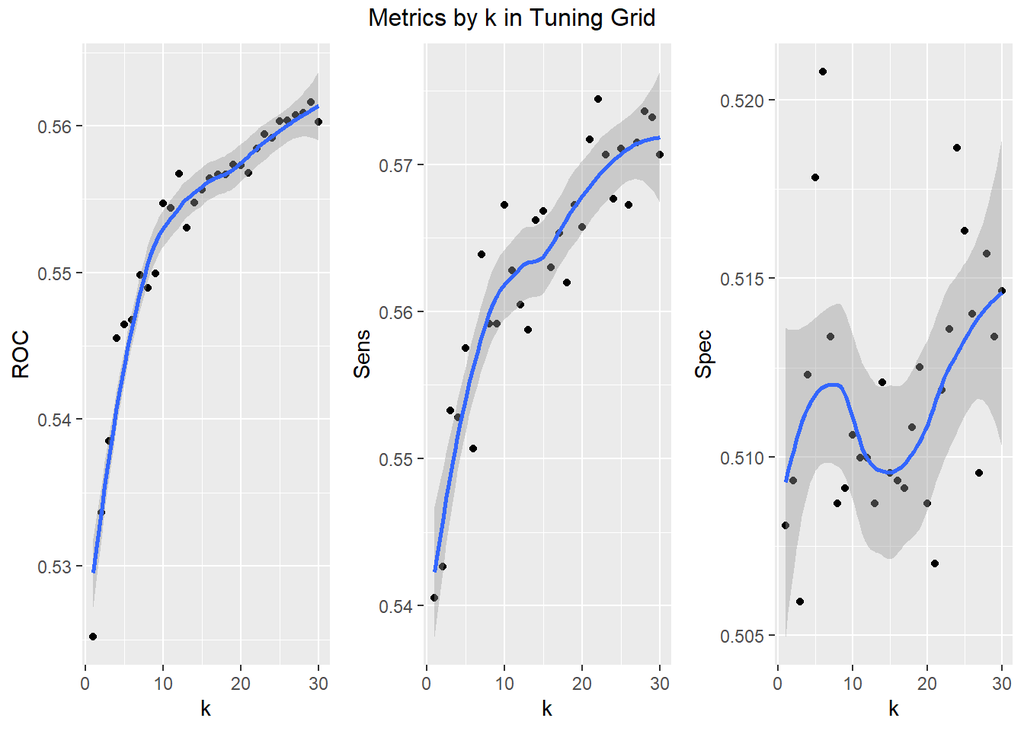

```r
# plot metrics by k tuning grid
knn.metrics <-data.frame(
  'k' = model.cv$results$k,
  'ROC' = model.cv$results$ROC,
  'Sens' = model.cv$results$Sens,
  'Spec' = model.cv$results$Spec)

p1 <- knn.metrics %>%
  ggplot(aes(x = k, y = ROC)) +
  geom_point() +
  geom_smooth(method = 'loess')

p2 <- knn.metrics %>%
  ggplot(aes(x = k, y = Sens)) +
  geom_point() +
  geom_smooth(method = 'loess')

p3 <- knn.metrics %>%
  ggplot(aes(x = k, y = Spec)) +
  geom_point() +
  geom_smooth(method = 'loess')

grid.arrange(p1, p2, p3, ncol = 3,
             top = 'Metrics by k in Tuning Grid')
```

```r
preds <- predict(model.cv, test2)

confusionMatrix(preds, test2$outcome)
```

```
## Confusion Matrix and Statistics
##
##           Reference
## Prediction   No  Yes
##        No  9171  734
##        Yes 6755  837
##
##                Accuracy : 0.572
##                  95% CI : (0.5646, 0.5793)
##     No Information Rate : 0.9102
##     P-Value [Acc > NIR] : 1
##
##                   Kappa : 0.0398
##
##  Mcnemar's Test P-Value : <2e-16
##
##             Sensitivity : 0.5759
##             Specificity : 0.5328
##          Pos Pred Value : 0.9259
##          Neg Pred Value : 0.1102
##              Prevalence : 0.9102
##          Detection Rate : 0.5241
##    Detection Prevalence : 0.5661
##       Balanced Accuracy : 0.5543
##
##        'Positive' Class : No
##
```

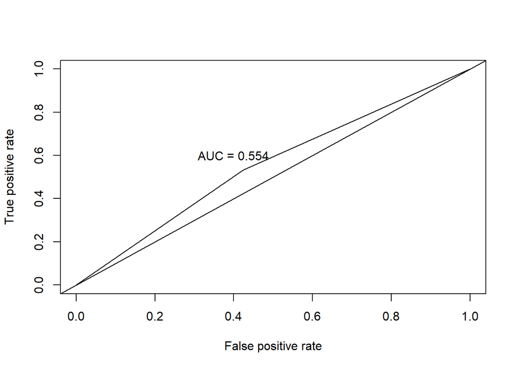

```r
#ROC curves
pred1 <- prediction(as.numeric(preds), test.y)
roc.perf1 = performance(pred1, measure = "tpr", x.measure = "fpr")
auc.val1 <- performance(pred1, measure = "auc")
auc.val1 <- auc.val1@y.values
plot(roc.perf1)
abline(a=0, b= 1)
text(x = .40, y = .6, paste("AUC = ", round(auc.val1[[1]], 3), sep = ""))
```

### HeatMap

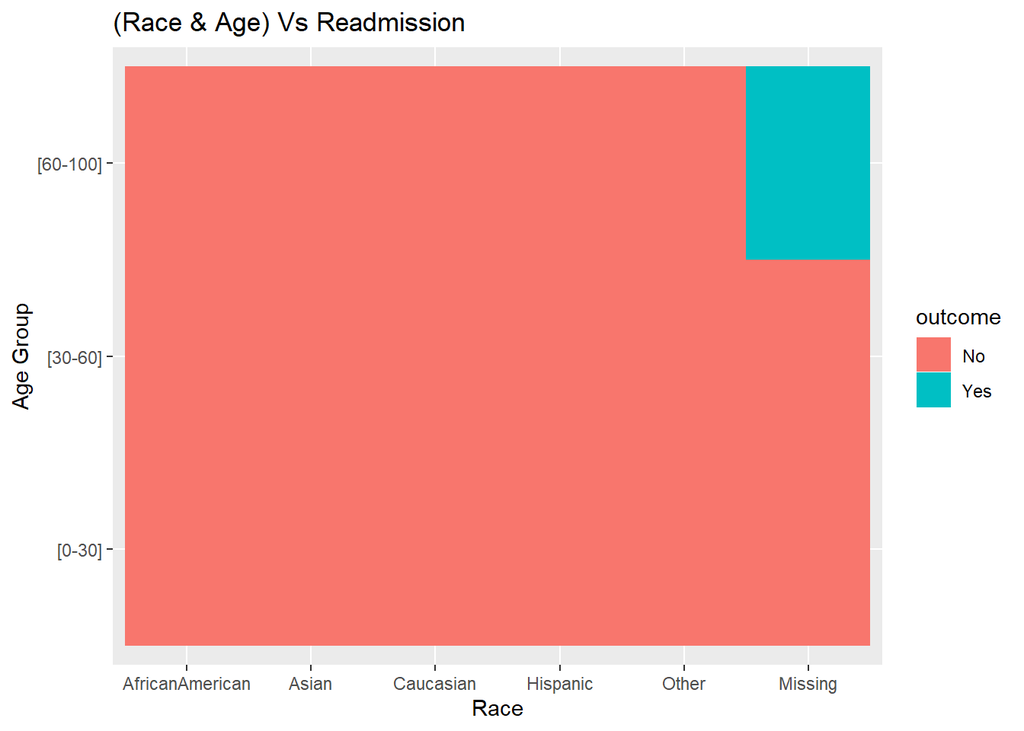

```r
ggplot(data = data,aes(x = race, y = ageGrp)) +labs(title="(Race & Age) Vs Readmission", y="Age Group", x="Race")+geom_tile(aes(fill = outcome))
```

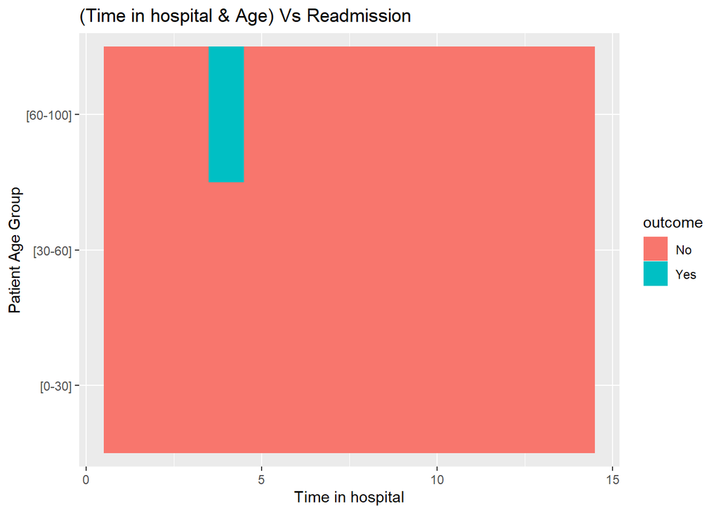

```r
ggplot(data = data, aes(x = time_in_hospital, y = ageGrp)) + labs(title="(Time in hospital & Age) Vs Readmission", y="Patient Age Group", x="Time in hospital") + geom_tile(aes(fill = outcome))
```

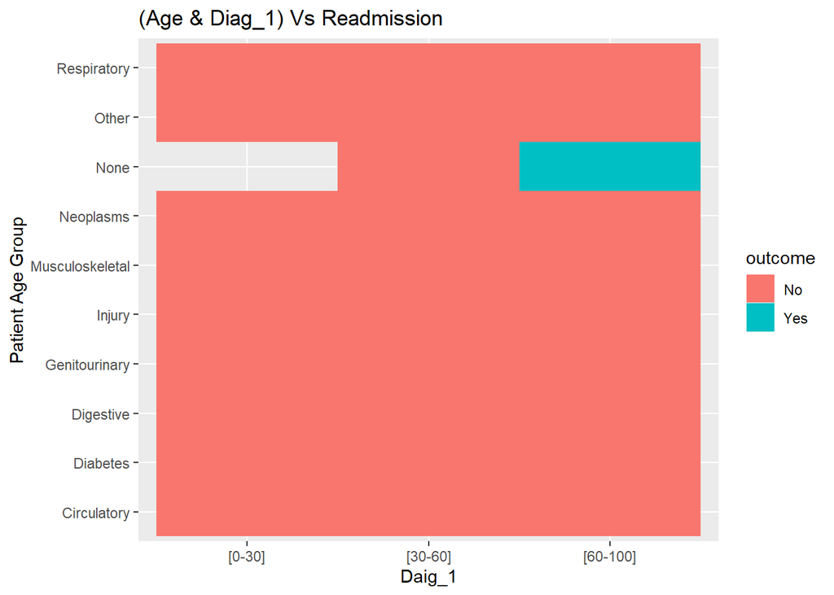

```r
ggplot(data = data, aes(x = ageGrp, y = diag_1)) + labs(title="(Age & Diag_1) Vs Readmission", y="Patient Age Group", x="Daig_1") + geom_tile(aes(fill = outcome))
```

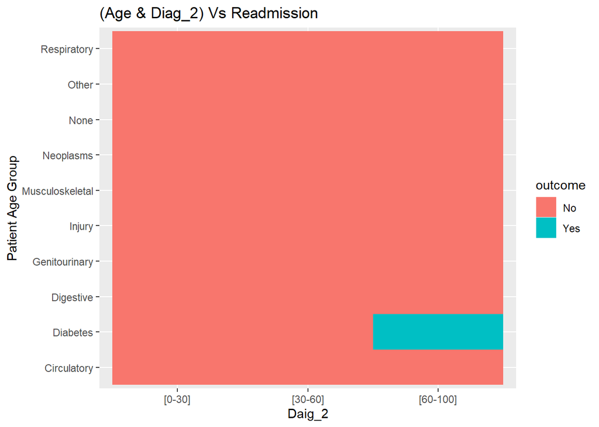

```r
ggplot(data = data, aes(x = ageGrp, y = diag_2)) + labs(title="(Age & Diag_2) Vs Readmission", y="Patient Age Group", x="Daig_2") + geom_tile(aes(fill = outcome))
```

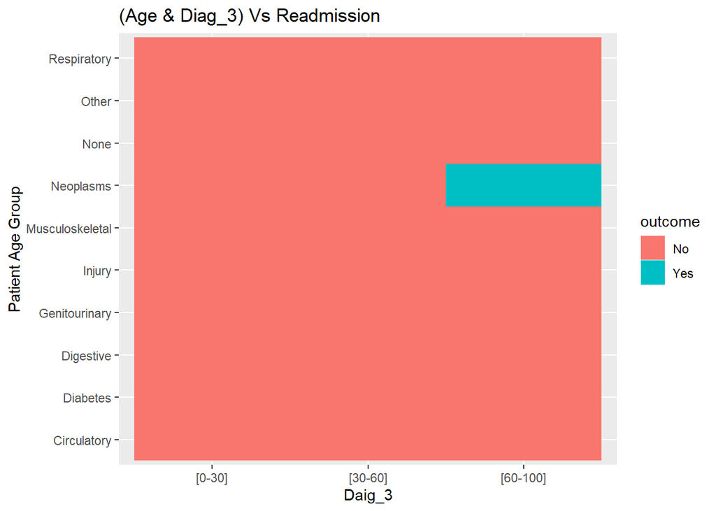

```r
ggplot(data = data, aes(x = data$ageGrp, y = data$diag_3)) + labs(title="(Age & Diag_3) Vs Readmission", y="Patient Age Group", x="Daig_3") + geom_tile(aes(fill = outcome))
```